# slide_deck slides

## PART II - FACTORS PREDICTING LOAN AMOUNTS AMONG BORROWERS

#### By ADEDAYO A. ADEDIRAN

## Investigation Overview

I explored the Loan Dataset by Prosper. My goal was to explore factors that affect the amount of loans borrowers received over time. To do this, I explored univariate, bivariate and multivariate visualizations of 15 selected variables to evaluate which of them better explained the differences in loan amounts received by borrowers. These variables include: Loan Status, Loan Original Amount, Borrower APR, Term, Prosper Score, Borrower State, Borrower Rate, Employment Status, Occupation, Is Borrower Homeowner, Stated Monthly Income, Debt To Income Ratio, and Loan Origination Date.

## Dataset Overview

This dataset contains 113,937 loans with 81 variables on each loan from 2005 to 2014. Some of the key variables in the dataset include loan amount, borrower rate (also know as the interest rate), Loan Status, Borrower Income, Borrower APR, TermProsperScore, Borrower State, Employment Status, Occupation, Loan Original Amount, etc. The dataset can be found [here](https://www.google.com/url?q=https://s3.amazonaws.com/udacity-hosted-downloads/ud651/prosperLoanData.csv&sa=D&ust=1554484977406000). The data dictionary explaining the variables in the data set can can be accessed [here](https://docs.google.com/spreadsheets/d/1gDyi_L4UvIrLTEC6Wri5nbaMmkGmLQBk-Yx3z0XDEtI/edit#gid=0). After dropping columns with lots of missing values, I am left with 70 features. Fortunately, there are no duplicated values in the dataset.

## Distribution of Loan Amounts

Borrowers can borrow from dollars 1,000 to 35000 dollars. The most popular Loan Original Amount is 4,000 dollars. An interesting fact to note is that loan amount in multiples of 5000s were very popular among borrowers. The distribution appears multimodal.

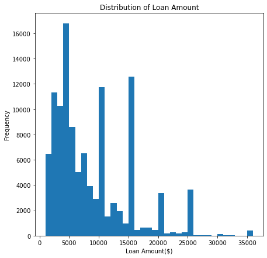

## Loan Amount Versus Prosper Score

From the plot, lower Prosper Score appear to be related with lower Amounts while higher amounts are correlated with higher prosper score. This is also in line with conventional finance. Borrowers with better credit score qualify for higher amounts.

[figure not shown]

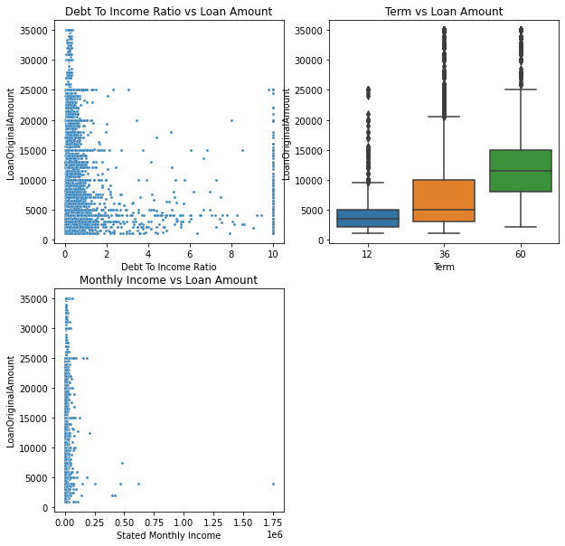

## Prosper Score vs Debt To Income Ratio vs Loan Amount

Borrowers who have high debt to income ratio and low prosper score (1-5) tend to receive less amounts when compared with those with low debt to income ratio and high prosper score. Further more, those with low debt to income ratio and high prosper score tend to receive the highest amount. While those with high debt to income ratio and low prosper score seem to receive the least amount.

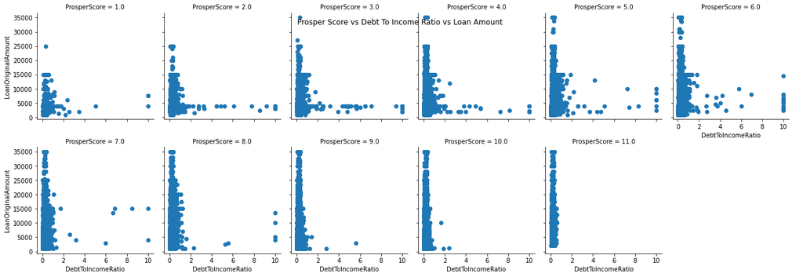

## 6. Loan Month versus Loan Amount versus Employment Status

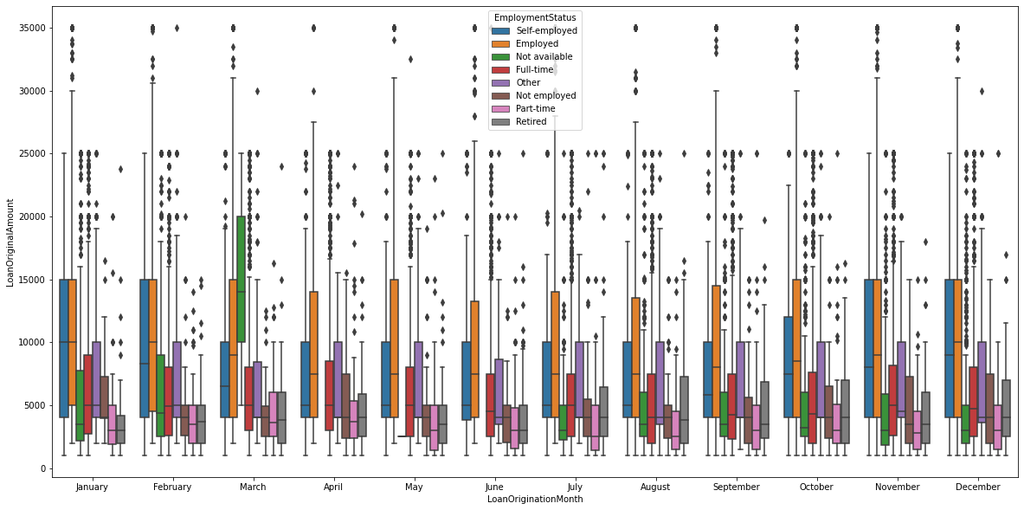